# Knox

Topics that will be discussed in this summary report for Knox County are

- Demographic Characteristics
  - Population growth from 1970 to 2020;
  - population density
  - sex, race, and age
  - educational level of the adult population
  - housing characteristics in terms of age of the housing stock and type of tenure
- Economic Characteristics
  - family income, household income, per capita income,
  - poverty status of families;
  - employment classification according to industry;
  - labor force by place of work and commuting patterns;

For more details on the data used, please see the Data Description tab.

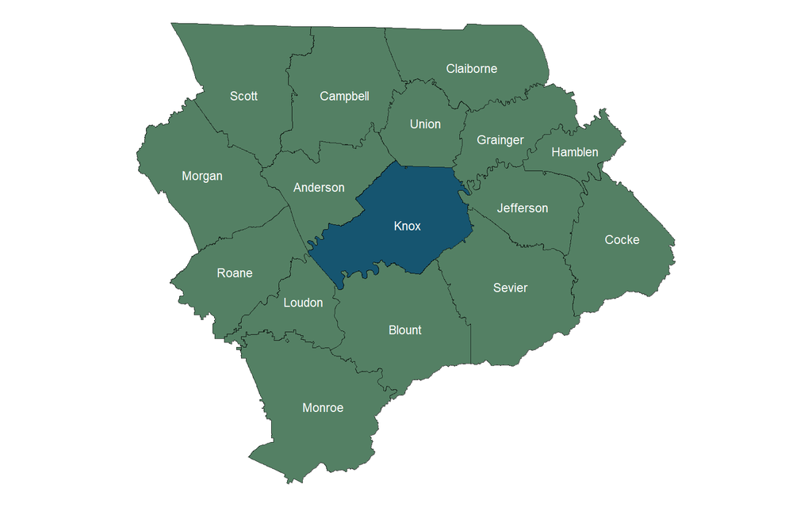

**Population and Growth**

| Place | 1970 | 1980 | 1990 | 2000 | 2010 | 2020 | Change 1970-1980 | Change 1980-1990 | Change 1990-2000 | Change 2000-2010 | Change 2010-2020 |
| --- | --- | --- | --- | --- | --- | --- | --- | --- | --- | --- | --- |
| Knox County | 276293 | 319694 | 335749 | 382032 | 432226 | 478971 | 43401 | 16055 | 46283 | 50194 | 46745 |
| Farragut |  |  | 12793 | 17720 | 20676 | 23506 |  |  | 4927 | 2956 | 2830 |
| Knoxville | 174587 | 175030 | 165121 | 173890 | 178874 | 190740 | 443 | -9909 | 8769 | 4984 | 11866 |

[interactive chart not shown]

IPUMS NHGIS, University of Minnesota, www.nhgis.org

**Population Density**

| Place | Area | Population Density |
| --- | --- | --- |
| Knox County | 525.8428791372221 | 910.8633377062608 |
| Farragut | 16.13804918972897 | 1456.557711756161 |
| Knoxville | 104.2364997023102 | 1829.877255517366 |

[interactive chart not shown]

source: U. S. Census Bureau *Decennial Census: Redistricting Data (PL 94-171)*, 2020, accessed June 2, 2026, http://api.census.gov/data/2020/dec/pl.

**Population Descriptions**

| Place | Year | Race Category | Number of People | Percentage of People |
| --- | --- | --- | --- | --- |
| Knox County | 2020 | Black | 40360 | 0.0582213073251233 |
| Knox County | 2020 | Other | 59101 | 0.08525613191828821 |
| Knox County | 2020 | White | 379510 | 0.5474620501228331 |
| Farragut | 2020 | Black | 444 | 0.0006404920825657767 |
| Farragut | 2020 | Other | 3118 | 0.004497870075315521 |
| Farragut | 2020 | White | 19944 | 0.02877021192498164 |
| Knoxville | 2020 | Black | 30477 | 0.04396458828909273 |
| Knoxville | 2020 | Other | 27477 | 0.03963693908256722 |
| Knoxville | 2020 | White | 132786 | 0.1915504091792325 |

| Place | Sex | Age Range | Year | Number of People | Percentage of People |
| --- | --- | --- | --- | --- | --- |
| Knox County | Female | 10 to 14 years | 2020 | 14234 | 0.02103191431201526 |
| Knox County | Female | 15 to 19 years | 2020 | 15032 | 0.0222110254277233 |
| Knox County | Female | 20 to 24 years | 2020 | 20523 | 0.03032443286676192 |
| Knox County | Female | 25 to 29 years | 2020 | 16635 | 0.02457959073910172 |
| Knox County | Female | 30 to 34 years | 2020 | 15754 | 0.02327784024669723 |
| Knox County | Female | 35 to 39 years | 2020 | 15803 | 0.02335024180643369 |
| Knox County | Female | 40 to 44 years | 2020 | 13771 | 0.02034779345164832 |
| Knox County | Female | 45 to 49 years | 2020 | 14891 | 0.02200268624562451 |
| Knox County | Female | 5 to 9 years | 2020 | 12550 | 0.01854366478964392 |
| Knox County | Female | 50 to 54 years | 2020 | 15197 | 0.02245482659826443 |

[output cut: 98 more lines]

[interactive chart not shown]

source: U. S. Census Bureau *Decennial Census: Redistricting Data (PL 94-171)*, 2020, accessed June 2, 2026, http://api.census.gov/data/2020/dec/pl.

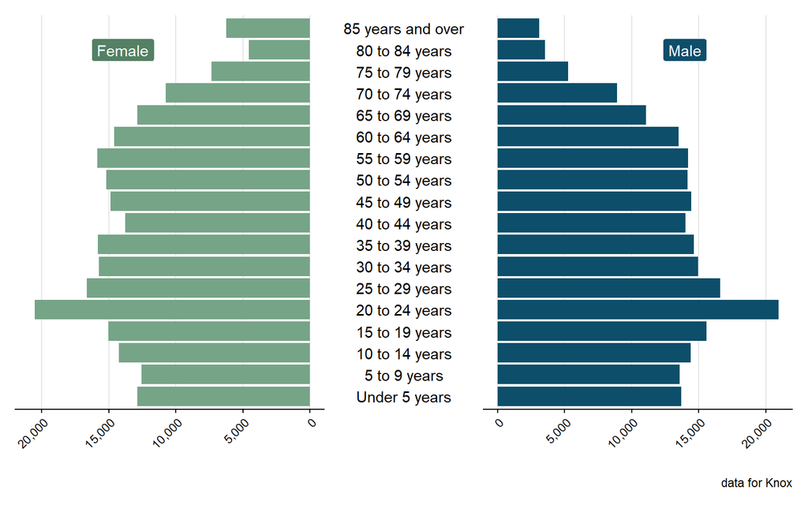

source: U. S. Census Bureau *American Community Survey 5-Year Estimates: Comparison Profiles 5-Year*, 2020, accessed June 2, 2026, http://api.census.gov/data/2020/acs/acs5.

**Education**

| Place | Level of Education | Year | Number of People | Percentage of People |
| --- | --- | --- | --- | --- |
| Knox County | 9th to 12th Grade, No Diploma | 2010 | 17162 | 0.04225064316399759 |
| Knox County | Associate's degree | 2010 | 20543 | 0.05057423158827656 |
| Knox County | Bachelor's degree | 2010 | 60161 | 0.148108667019535 |
| Knox County | Graduate or Professional Degree | 2010 | 34583 | 0.08513891111412007 |
| Knox County | Less Than 9th Grade | 2010 | 10754 | 0.02647496891886902 |
| Knox County | Some College, No Degree | 2010 | 56690 | 0.139563510136757 |
| Knox County | Total | 2010 | 280049 | 0.6894447248242839 |
| Knox County | 9th to 12th Grade, No Diploma | 2020 | 12386 | 0.02761594527646045 |
| Knox County | Associate's degree | 2020 | 27242 | 0.06073902641864489 |
| Knox County | Bachelor's degree | 2020 | 73405 | 0.1636644972564653 |

[output cut: 32 more lines]

[interactive chart not shown]

source: U. S. Census Bureau *American Community Survey 5-Year Estimates: Comparison Profiles 5-Year*, 2020, accessed June 2, 2026, http://api.census.gov/data/2020/acs/acs5.

**Housing Units by Year of Construction**

| Place | Year | 1939 or earlier | 1940-1959 | 1960-1979 | 1980 to 1989 | 1990 to 1999 | 2000 to 2004 | 2005 or later | 2000 to 2009 | 2010 or later | Total |
| --- | --- | --- | --- | --- | --- | --- | --- | --- | --- | --- | --- |
| Knox County | 2010 | 10901 | 26811 | 60424 | 30025 | 35710 | 17881 | 10724 |  |  | 192476 |
| Knox County | 2020 | 14533 | 29028 | 52662 | 28198 | 35482 |  |  | 31815 | 15893 | 207611 |
| Farragut | 2010 | 79 | 257 | 2035 | 1837 | 2151 | 900 | 323 |  |  | 7582 |
| Knoxville | 2010 | 8094 | 19735 | 32181 | 11436 | 10474 | 5357 | 3535 |  |  | 90812 |
| Farragut | 2020 | 156 | 92 | 2324 | 1920 | 2112 |  |  | 1727 | 826 | 9157 |
| Knoxville | 2020 | 11429 | 20843 | 24811 | 10484 | 10591 |  |  | 8801 | 5435 | 92394 |

[interactive chart not shown]

source: U. S. Census Bureau *Decennial Census: Redistricting Data (PL 94-171)*, 2020, accessed June 2, 2026, http://api.census.gov/data/2020/dec/pl.

**Housing Units by Type of Tenure**

| Place | Year | Own | Rent | Total |
| --- | --- | --- | --- | --- |
| Knox County | 2010 | 119607 | 58248 | 177855 |
| Knox County | 2020 | 123272 | 66264 | 189536 |
| Farragut | 2010 | 6649 | 647 | 7296 |
| Knoxville | 2010 | 42344 | 39772 | 82116 |
| Farragut | 2020 | 7712 | 1158 | 8870 |
| Knoxville | 2020 | 38490 | 43598 | 82088 |

[interactive chart not shown]

source: U. S. Census Bureau *Decennial Census: Redistricting Data (PL 94-171)*, 2020, accessed June 2, 2026, http://api.census.gov/data/2020/dec/pl.

**Income Comparison**

| Place | Year | Median Family Income | Median Household Income | Per Capita Income |
| --- | --- | --- | --- | --- |
| Knox County | 2020 | 79265 | 59250 | 34338 |
| Farragut | 2020 | 126132 | 109156 | 56116 |
| Knoxville | 2020 | 55835 | 41598 | 26903 |

[interactive chart not shown]

source: U. S. Census Bureau *Decennial Census: Redistricting Data (PL 94-171)*, 2020, accessed June 2, 2026, http://api.census.gov/data/2020/dec/pl.

**Povery Status**

| Place | Year | Above Poverty | Below Poverty |
| --- | --- | --- | --- |
| Knox County | 2020 | 106713 | 9915 |
| Farragut | 2020 | 6657 | 176 |
| Knoxville | 2020 | 33149 | 6290 |

[interactive chart not shown]

source: U. S. Census Bureau *American Community Survey 5-Year Estimates: Comparison Profiles 5-Year*, 2020, accessed June 2, 2026, http://api.census.gov/data/2020/acs/acs5.

**Poverty Status by Family Type**

| Place | Poverty Status | Family Type | Number of Families | Year | Percentage of Families |
| --- | --- | --- | --- | --- | --- |
| Knox County | Above Poverty | All Families | 106713 | 2020 | 0.6550828729281768 |
| Knox County | Above Poverty | Female Householder | 15214 | 2020 | 0.09339472068753837 |
| Knox County | Above Poverty | Female Householder with related children | 8571 | 2020 | 0.05261510128913444 |
| Knox County | Below Poverty | All Families | 9915 | 2020 | 0.06086556169429098 |
| Knox County | Below Poverty | Female Householder | 5413 | 2020 | 0.03322897483118478 |
| Knox County | Below Poverty | Female Householder with related children | 4753 | 2020 | 0.02917740945365255 |
| Farragut | Above Poverty | All Families | 6657 | 2020 | 0.04086556169429097 |
| Farragut | Above Poverty | Female Householder | 454 | 2020 | 0.002786985880908533 |
| Farragut | Above Poverty | Female Householder with related children | 194 | 2020 | 0.001190914671577655 |
| Farragut | Below Poverty | All Families | 176 | 2020 | 0.001080417434008594 |

[output cut: 8 more lines]

[interactive chart not shown]

source: U. S. Census Bureau *American Community Survey 5-Year Estimates: Comparison Profiles 5-Year*, 2020, accessed June 2, 2026, http://api.census.gov/data/2020/acs/acs5.

**Employment by Industry**

| Place | Industry | Year | Number of Jobs | Percentage of Jobs |
| --- | --- | --- | --- | --- |
| Farragut | Arts, Entertainment, And Recreation, And Accommodation And Food Services | 2010 | 484 | 0.05237528406016665 |
| Farragut | Arts, Entertainment, And Recreation, And Accommodation And Food Services | 2020 | 742 | 0.003177185921041363 |
| Farragut | Educational Services, And Health Care And Social Assistance | 2010 | 1866 | 0.2019261984633698 |
| Farragut | Educational Services, And Health Care And Social Assistance | 2020 | 2299 | 0.00984413804915646 |
| Farragut | Manufacturing | 2010 | 855 | 0.09252245427983985 |
| Farragut | Manufacturing | 2020 | 929 | 0.003977905283891411 |
| Farragut | Other Industries | 2010 | 4880 | 0.5280813764744076 |
| Farragut | Other Industries | 2020 | 3508 | 0.01502098141645971 |
| Farragut | Professional, Scientific, And Management, And Administrative, And Waste Management Services | 2020 | 2008 | 0.1821150009069472 |
| Farragut | Retail Trade | 2010 | 1156 | 0.1250946867222162 |

[output cut: 23 more lines]

[interactive chart not shown]

source: U. S. Census Bureau *American Community Survey 5-Year Estimates: Comparison Profiles 5-Year*, 2020, accessed June 2, 2026, http://api.census.gov/data/2020/acs/acs5.

**Employment by Industry (Historical)**

| Place | Year | Industry | Number of Jobs | Percentage of Jobs |
| --- | --- | --- | --- | --- |
| Farragut | 2010 | Agriculture, Forestry, Fishing And Hunting, And Mining | 44 | 0.0001453128354167011 |
| Farragut | 2010 | Construction | 370 | 0.001221948843276804 |
| Farragut | 2010 | Manufacturing | 855 | 0.002823692597301805 |
| Farragut | 2010 | Other | 403 | 0.00133093346983933 |
| Farragut | 2010 | Professional Services | 4530 | 0.01496061691903763 |
| Farragut | 2010 | Public Administration | 300 | 0.0009907693323865981 |
| Farragut | 2010 | Trade, Finance, Insurance &amp; Real Estate | 2739 | 0.00904572400468964 |
| Farragut | 2020 | Agriculture, Forestry, Fishing And Hunting, And Mining | 21 | 6.209104913176017e-05 |
| Farragut | 2020 | Construction | 916 | 0.002708352428794872 |
| Farragut | 2020 | Manufacturing | 929 | 0.002746789744924057 |

[output cut: 32 more lines]

**Labor Force by Place of Work**

| Place | Year | Work Out Of State | Work Out of County of Residence | Work in County of Residence |
| --- | --- | --- | --- | --- |
| Knox County | 2020 | 2092 | 35705 | 192188 |
| Farragut | 2020 | 120 | 2718 | 8064 |
| Knoxville | 2020 | 648 | 11070 | 80116 |

[interactive chart not shown]

source: U. S. Census Bureau *American Community Survey 5-Year Estimates: Comparison Profiles 5-Year*, 2020, accessed June 2, 2026, http://api.census.gov/data/2020/acs/acs5.

**Commuting Patterns**

| Home County | Year | Number of Jobs | Percentage of Jobs |
| --- | --- | --- | --- |
| Knox | 2020 | 131365 | 0.2904255624901895 |
| Knox | 2010 | 120552 | 0.2665198676155545 |
| Blount | 2020 | 17738 | 0.0392156862745098 |
| Blount | 2010 | 15928 | 0.0352140856342537 |
| Anderson | 2020 | 11122 | 0.02458884106128639 |
| Anderson | 2010 | 9242 | 0.02043248238521928 |
| Sevier | 2020 | 8418 | 0.0186107592208154 |
| Sevier | 2010 | 8116 | 0.01794308883774504 |
| Davidson | 2010 | 4005 | 0.008854370477472758 |
| Davidson | 2020 | 3731 | 0.008248603308726806 |

[output cut: 3 more lines]

| Work County | Year | Number of Jobs | Percentage of Jobs |
| --- | --- | --- | --- |
| Knox | 2020 | 131365 | 0.2904255624901895 |
| Knox | 2010 | 120552 | 0.2665198676155545 |
| Anderson | 2020 | 17129 | 0.03786929136295402 |
| Anderson | 2010 | 13666 | 0.03021319024847508 |
| Blount | 2020 | 11626 | 0.02570309891912566 |
| Blount | 2010 | 8179 | 0.01808237106997495 |
| Sevier | 2020 | 5018 | 0.01109394033856637 |
| Sevier | 2010 | 3599 | 0.007956773869768901 |
| Loudon | 2020 | 2721 | 0.00601566593488224 |
| Loudon | 2010 | 2064 | 0.004563151227341766 |

[output cut: 3 more lines]

[interactive chart not shown]

source: U. S. Census Bureau *Tn_od_main_JT00_2020*, LEHD Origin-Destination Employment Statistics, 8.3, 2020, accessed June 2, 2026, https://lehd.ces.census.gov/data/lodes/.

## References

Bureau, U. S. Census. *American Community Survey 5-Year Estimates: Comparison Profiles 5-Year*. 2020. Accessed June 2, 2026. http://api.census.gov/data/2020/acs/acs5.

Bureau, U. S. Census. *Decennial Census: Redistricting Data (PL 94-171)*. 2020. Accessed June 2, 2026. http://api.census.gov/data/2020/dec/pl.

Bureau, U. S. Census. *Tn_od_main_JT00_2020*. LEHD Origin-Destination Employment Statistics, 8.3. 2020. Accessed June 2, 2026. https://lehd.ces.census.gov/data/lodes/.